# Risk Factor Analysis

## Outcome Variable

**Outcome Variable:** sstunted

## Predictor Variables

**Intervention Variable:** brthmon

**Adjustment Set:**

unadjusted

## Stratifying Variables

The analysis was stratified on these variable(s):

- agecat
- studyid

The following strata were considered:

- agecat: 12 months, studyid: ki0047075b-MAL-ED
- agecat: 12 months, studyid: ki1000108-CMC-V-BCS-2002
- agecat: 12 months, studyid: ki1000108-IRC
- agecat: 12 months, studyid: ki1000109-EE
- agecat: 12 months, studyid: ki1000109-ResPak
- agecat: 12 months, studyid: ki1000304b-SAS-FoodSuppl
- agecat: 12 months, studyid: ki1017093-NIH-Birth
- agecat: 12 months, studyid: ki1066203-TanzaniaChild2
- agecat: 12 months, studyid: ki1101329-Keneba
- agecat: 12 months, studyid: ki1112895-Guatemala BSC
- agecat: 12 months, studyid: ki1113344-GMS-Nepal
- agecat: 12 months, studyid: ki1114097-CMIN
- agecat: 12 months, studyid: ki1114097-CONTENT
- agecat: 12 months, studyid: ki1126311-ZVITAMBO
- agecat: 12 months, studyid: ki1148112-LCNI-5
- agecat: 18 months, studyid: ki0047075b-MAL-ED
- agecat: 18 months, studyid: ki1000108-CMC-V-BCS-2002
- agecat: 18 months, studyid: ki1000108-IRC
- agecat: 18 months, studyid: ki1000109-EE
- agecat: 18 months, studyid: ki1000109-ResPak
- agecat: 18 months, studyid: ki1000304b-SAS-FoodSuppl
- agecat: 18 months, studyid: ki1017093-NIH-Birth
- agecat: 18 months, studyid: ki1066203-TanzaniaChild2
- agecat: 18 months, studyid: ki1101329-Keneba
- agecat: 18 months, studyid: ki1113344-GMS-Nepal
- agecat: 18 months, studyid: ki1114097-CMIN
- agecat: 18 months, studyid: ki1114097-CONTENT
- agecat: 18 months, studyid: ki1126311-ZVITAMBO
- agecat: 18 months, studyid: ki1148112-LCNI-5
- agecat: 24 months, studyid: ki0047075b-MAL-ED
- agecat: 24 months, studyid: ki1000108-CMC-V-BCS-2002
- agecat: 24 months, studyid: ki1000108-IRC
- agecat: 24 months, studyid: ki1017093-NIH-Birth
- agecat: 24 months, studyid: ki1066203-TanzaniaChild2
- agecat: 24 months, studyid: ki1101329-Keneba
- agecat: 24 months, studyid: ki1113344-GMS-Nepal
- agecat: 24 months, studyid: ki1114097-CMIN
- agecat: 24 months, studyid: ki1114097-CONTENT
- agecat: 24 months, studyid: ki1126311-ZVITAMBO
- agecat: 24 months, studyid: ki1148112-LCNI-5
- agecat: 3 months, studyid: ki0047075b-MAL-ED
- agecat: 3 months, studyid: ki1000108-CMC-V-BCS-2002
- agecat: 3 months, studyid: ki1000108-IRC
- agecat: 3 months, studyid: ki1000109-EE
- agecat: 3 months, studyid: ki1000109-ResPak
- agecat: 3 months, studyid: ki1000304b-SAS-FoodSuppl
- agecat: 3 months, studyid: ki1017093-NIH-Birth
- agecat: 3 months, studyid: ki1066203-TanzaniaChild2
- agecat: 3 months, studyid: ki1101329-Keneba
- agecat: 3 months, studyid: ki1112895-Guatemala BSC
- agecat: 3 months, studyid: ki1113344-GMS-Nepal
- agecat: 3 months, studyid: ki1114097-CMIN
- agecat: 3 months, studyid: ki1114097-CONTENT
- agecat: 3 months, studyid: ki1126311-ZVITAMBO
- agecat: 6 months, studyid: ki0047075b-MAL-ED
- agecat: 6 months, studyid: ki1000108-CMC-V-BCS-2002
- agecat: 6 months, studyid: ki1000108-IRC
- agecat: 6 months, studyid: ki1000109-EE
- agecat: 6 months, studyid: ki1000109-ResPak
- agecat: 6 months, studyid: ki1000304b-SAS-FoodSuppl
- agecat: 6 months, studyid: ki1017093-NIH-Birth
- agecat: 6 months, studyid: ki1066203-TanzaniaChild2
- agecat: 6 months, studyid: ki1101329-Keneba
- agecat: 6 months, studyid: ki1112895-Guatemala BSC
- agecat: 6 months, studyid: ki1113344-GMS-Nepal
- agecat: 6 months, studyid: ki1114097-CMIN
- agecat: 6 months, studyid: ki1114097-CONTENT
- agecat: 6 months, studyid: ki1126311-ZVITAMBO
- agecat: 6 months, studyid: ki1148112-LCNI-5
- agecat: 9 months, studyid: ki0047075b-MAL-ED
- agecat: 9 months, studyid: ki1000108-CMC-V-BCS-2002
- agecat: 9 months, studyid: ki1000108-IRC
- agecat: 9 months, studyid: ki1000109-EE
- agecat: 9 months, studyid: ki1000109-ResPak
- agecat: 9 months, studyid: ki1000304b-SAS-FoodSuppl
- agecat: 9 months, studyid: ki1017093-NIH-Birth
- agecat: 9 months, studyid: ki1066203-TanzaniaChild2
- agecat: 9 months, studyid: ki1101329-Keneba
- agecat: 9 months, studyid: ki1112895-Guatemala BSC
- agecat: 9 months, studyid: ki1113344-GMS-Nepal
- agecat: 9 months, studyid: ki1114097-CMIN
- agecat: 9 months, studyid: ki1114097-CONTENT
- agecat: 9 months, studyid: ki1126311-ZVITAMBO
- agecat: 9 months, studyid: ki1148112-LCNI-5
- agecat: Birth, studyid: ki0047075b-MAL-ED
- agecat: Birth, studyid: ki1000108-CMC-V-BCS-2002
- agecat: Birth, studyid: ki1000108-IRC
- agecat: Birth, studyid: ki1000109-EE
- agecat: Birth, studyid: ki1000109-ResPak
- agecat: Birth, studyid: ki1017093-NIH-Birth
- agecat: Birth, studyid: ki1101329-Keneba
- agecat: Birth, studyid: ki1114097-CMIN
- agecat: Birth, studyid: ki1114097-CONTENT
- agecat: Birth, studyid: ki1126311-ZVITAMBO

### Dropped Strata

Some strata were dropped due to rare outcomes:

- agecat: Birth, studyid: ki0047075b-MAL-ED
- agecat: Birth, studyid: ki1000108-CMC-V-BCS-2002
- agecat: Birth, studyid: ki1000108-IRC
- agecat: Birth, studyid: ki1000109-EE
- agecat: Birth, studyid: ki1000109-ResPak
- agecat: Birth, studyid: ki1017093-NIH-Birth
- agecat: Birth, studyid: ki1101329-Keneba
- agecat: Birth, studyid: ki1114097-CMIN
- agecat: Birth, studyid: ki1114097-CONTENT
- agecat: Birth, studyid: ki1126311-ZVITAMBO
- agecat: 3 months, studyid: ki0047075b-MAL-ED
- agecat: 3 months, studyid: ki1000108-CMC-V-BCS-2002
- agecat: 3 months, studyid: ki1000108-IRC
- agecat: 3 months, studyid: ki1000109-EE
- agecat: 3 months, studyid: ki1000109-ResPak
- agecat: 3 months, studyid: ki1000304b-SAS-FoodSuppl
- agecat: 3 months, studyid: ki1017093-NIH-Birth
- agecat: 3 months, studyid: ki1066203-TanzaniaChild2
- agecat: 3 months, studyid: ki1101329-Keneba
- agecat: 3 months, studyid: ki1112895-Guatemala BSC
- agecat: 3 months, studyid: ki1113344-GMS-Nepal
- agecat: 3 months, studyid: ki1114097-CMIN
- agecat: 3 months, studyid: ki1114097-CONTENT
- agecat: 6 months, studyid: ki0047075b-MAL-ED
- agecat: 6 months, studyid: ki1000108-CMC-V-BCS-2002
- agecat: 6 months, studyid: ki1000108-IRC
- agecat: 6 months, studyid: ki1000109-EE
- agecat: 6 months, studyid: ki1000109-ResPak
- agecat: 6 months, studyid: ki1000304b-SAS-FoodSuppl
- agecat: 6 months, studyid: ki1017093-NIH-Birth
- agecat: 6 months, studyid: ki1066203-TanzaniaChild2
- agecat: 6 months, studyid: ki1101329-Keneba
- agecat: 6 months, studyid: ki1112895-Guatemala BSC
- agecat: 6 months, studyid: ki1113344-GMS-Nepal
- agecat: 6 months, studyid: ki1114097-CMIN
- agecat: 6 months, studyid: ki1114097-CONTENT
- agecat: 6 months, studyid: ki1126311-ZVITAMBO
- agecat: 6 months, studyid: ki1148112-LCNI-5
- agecat: 9 months, studyid: ki0047075b-MAL-ED
- agecat: 9 months, studyid: ki1000108-CMC-V-BCS-2002
- agecat: 9 months, studyid: ki1000108-IRC
- agecat: 9 months, studyid: ki1000109-EE
- agecat: 9 months, studyid: ki1000109-ResPak
- agecat: 9 months, studyid: ki1000304b-SAS-FoodSuppl
- agecat: 9 months, studyid: ki1017093-NIH-Birth
- agecat: 9 months, studyid: ki1066203-TanzaniaChild2
- agecat: 9 months, studyid: ki1112895-Guatemala BSC
- agecat: 9 months, studyid: ki1113344-GMS-Nepal
- agecat: 9 months, studyid: ki1114097-CMIN
- agecat: 9 months, studyid: ki1114097-CONTENT
- agecat: 9 months, studyid: ki1126311-ZVITAMBO
- agecat: 9 months, studyid: ki1148112-LCNI-5
- agecat: 12 months, studyid: ki0047075b-MAL-ED
- agecat: 12 months, studyid: ki1000108-CMC-V-BCS-2002
- agecat: 12 months, studyid: ki1000108-IRC
- agecat: 12 months, studyid: ki1000109-EE
- agecat: 12 months, studyid: ki1000109-ResPak
- agecat: 12 months, studyid: ki1000304b-SAS-FoodSuppl
- agecat: 12 months, studyid: ki1017093-NIH-Birth
- agecat: 12 months, studyid: ki1066203-TanzaniaChild2
- agecat: 12 months, studyid: ki1112895-Guatemala BSC
- agecat: 12 months, studyid: ki1113344-GMS-Nepal
- agecat: 12 months, studyid: ki1114097-CONTENT
- agecat: 12 months, studyid: ki1126311-ZVITAMBO
- agecat: 12 months, studyid: ki1148112-LCNI-5
- agecat: 18 months, studyid: ki1000108-CMC-V-BCS-2002
- agecat: 18 months, studyid: ki1000108-IRC
- agecat: 18 months, studyid: ki1000109-EE
- agecat: 18 months, studyid: ki1000109-ResPak
- agecat: 18 months, studyid: ki1000304b-SAS-FoodSuppl
- agecat: 18 months, studyid: ki1017093-NIH-Birth
- agecat: 18 months, studyid: ki1066203-TanzaniaChild2
- agecat: 18 months, studyid: ki1113344-GMS-Nepal
- agecat: 18 months, studyid: ki1114097-CONTENT
- agecat: 18 months, studyid: ki1126311-ZVITAMBO
- agecat: 18 months, studyid: ki1148112-LCNI-5
- agecat: 24 months, studyid: ki1000108-CMC-V-BCS-2002
- agecat: 24 months, studyid: ki1000108-IRC
- agecat: 24 months, studyid: ki1017093-NIH-Birth
- agecat: 24 months, studyid: ki1066203-TanzaniaChild2
- agecat: 24 months, studyid: ki1113344-GMS-Nepal
- agecat: 24 months, studyid: ki1114097-CONTENT
- agecat: 24 months, studyid: ki1126311-ZVITAMBO
- agecat: 24 months, studyid: ki1148112-LCNI-5

## Methods Detail

We’re interested in the causal parameters $E[Y_a]$ for all values of $a \in \mathcal{A}$. These parameters represent the mean outcome if, possibly contrary to fact, we intervened to set all units to have $A=a$. Under the randomization and positivity assumptions, these are identified by the statistical parameters $\psi_a=E_W[E_{Y|A,W}(Y|A=a,W)]$. In addition, we’re interested in the mean of $Y$, $E[Y]$ under no intervention (the observed mean). We will estimate these parameters by using SuperLearner to fit the relevant likelihood factors – $E_{Y|A,W}(Y|A=a,W)$ and $p(A=a|W)$, and then updating our likelihood fit using a joint TMLE.

For unadjusted analyses ($W=\{\}$), initial likelihoods were estimated using Lrnr_glm to estimate the simple $E(Y|A)$ and Lrnr_mean to estimate $p(A)$. For adjusted analyses, a small library containing Lrnr_glmnet, Lrnr_xgboost, and Lrnr_mean was used.

Having estimated these parameters, we will then use the delta method to estimate relative risks and attributable risks relative to a prespecified baseline level of $A$.

# Results Detail

## Results Plots

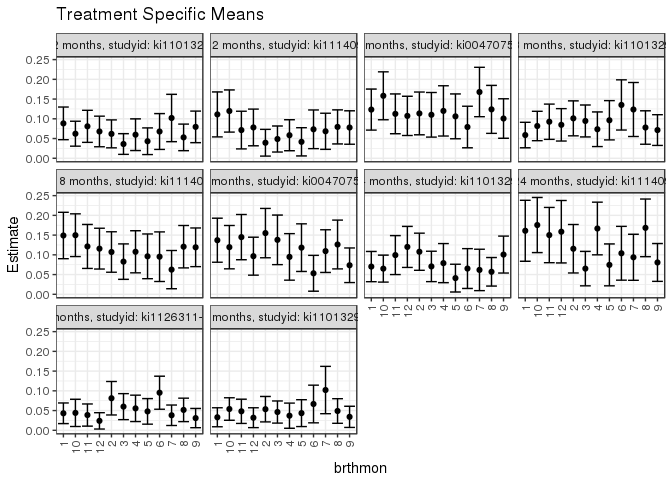

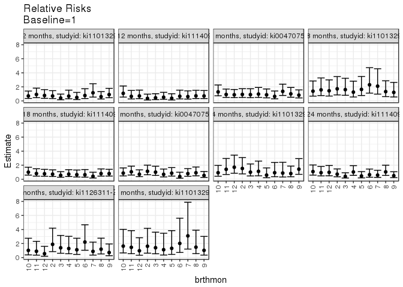

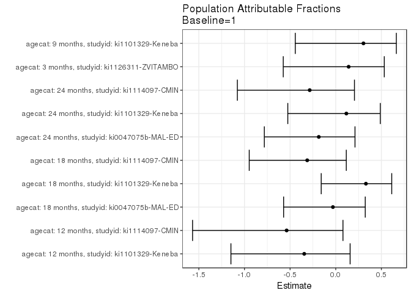

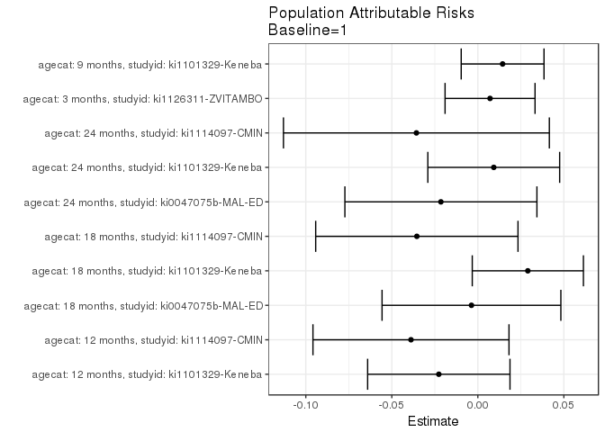

## Data Summary

| agecat | studyid | A | n | nA | nAY0 | nAY1 |
| --- | --- | --- | --- | --- | --- | --- |
| Birth | ki0047075b-MAL-ED | 1 | 1499 | 141 | 135 | 6 |
| Birth | ki0047075b-MAL-ED | 2 | 1499 | 128 | 125 | 3 |
| Birth | ki0047075b-MAL-ED | 3 | 1499 | 123 | 122 | 1 |
| Birth | ki0047075b-MAL-ED | 4 | 1499 | 99 | 97 | 2 |
| Birth | ki0047075b-MAL-ED | 5 | 1499 | 115 | 110 | 5 |
| Birth | ki0047075b-MAL-ED | 6 | 1499 | 92 | 91 | 1 |
| Birth | ki0047075b-MAL-ED | 7 | 1499 | 132 | 128 | 4 |
| Birth | ki0047075b-MAL-ED | 8 | 1499 | 110 | 106 | 4 |
| Birth | ki0047075b-MAL-ED | 9 | 1499 | 139 | 131 | 8 |
| Birth | ki0047075b-MAL-ED | 10 | 1499 | 141 | 135 | 6 |
| Birth | ki0047075b-MAL-ED | 11 | 1499 | 143 | 140 | 3 |
| Birth | ki0047075b-MAL-ED | 12 | 1499 | 136 | 133 | 3 |
| Birth | ki1000108-CMC-V-BCS-2002 | 1 | 90 | 9 | 9 | 0 |
| Birth | ki1000108-CMC-V-BCS-2002 | 2 | 90 | 1 | 1 | 0 |
| Birth | ki1000108-CMC-V-BCS-2002 | 3 | 90 | 8 | 7 | 1 |
| Birth | ki1000108-CMC-V-BCS-2002 | 4 | 90 | 9 | 9 | 0 |
| Birth | ki1000108-CMC-V-BCS-2002 | 5 | 90 | 11 | 11 | 0 |
| Birth | ki1000108-CMC-V-BCS-2002 | 6 | 90 | 9 | 9 | 0 |
| Birth | ki1000108-CMC-V-BCS-2002 | 7 | 90 | 7 | 7 | 0 |
| Birth | ki1000108-CMC-V-BCS-2002 | 8 | 90 | 4 | 4 | 0 |
| Birth | ki1000108-CMC-V-BCS-2002 | 9 | 90 | 7 | 7 | 0 |
| Birth | ki1000108-CMC-V-BCS-2002 | 10 | 90 | 10 | 9 | 1 |
| Birth | ki1000108-CMC-V-BCS-2002 | 11 | 90 | 11 | 11 | 0 |
| Birth | ki1000108-CMC-V-BCS-2002 | 12 | 90 | 4 | 3 | 1 |
| Birth | ki1000108-IRC | 1 | 388 | 35 | 32 | 3 |
| Birth | ki1000108-IRC | 2 | 388 | 26 | 25 | 1 |
| Birth | ki1000108-IRC | 3 | 388 | 26 | 26 | 0 |
| Birth | ki1000108-IRC | 4 | 388 | 21 | 21 | 0 |
| Birth | ki1000108-IRC | 5 | 388 | 22 | 21 | 1 |
| Birth | ki1000108-IRC | 6 | 388 | 34 | 31 | 3 |

[output cut: 1230 more lines]

## Results Table

### Parameter: TSM

| agecat | studyid | intervention_level | baseline_level | estimate | ci_lower | ci_upper |
| --- | --- | --- | --- | --- | --- | --- |
| 3 months | ki1126311-ZVITAMBO | 1 | NA | 0.0431034 | 0.0169645 | 0.0692424 |
| 3 months | ki1126311-ZVITAMBO | 2 | NA | 0.0812500 | 0.0389058 | 0.1235942 |
| 3 months | ki1126311-ZVITAMBO | 3 | NA | 0.0600000 | 0.0270794 | 0.0929206 |
| 3 months | ki1126311-ZVITAMBO | 4 | NA | 0.0555556 | 0.0220853 | 0.0890258 |
| 3 months | ki1126311-ZVITAMBO | 5 | NA | 0.0479042 | 0.0155066 | 0.0803018 |
| 3 months | ki1126311-ZVITAMBO | 6 | NA | 0.0952381 | 0.0533794 | 0.1370968 |
| 3 months | ki1126311-ZVITAMBO | 7 | NA | 0.0380952 | 0.0121991 | 0.0639914 |
| 3 months | ki1126311-ZVITAMBO | 8 | NA | 0.0516432 | 0.0219165 | 0.0813699 |
| 3 months | ki1126311-ZVITAMBO | 9 | NA | 0.0309278 | 0.0065612 | 0.0552945 |
| 3 months | ki1126311-ZVITAMBO | 10 | NA | 0.0441176 | 0.0095967 | 0.0786386 |
| 3 months | ki1126311-ZVITAMBO | 11 | NA | 0.0386740 | 0.0105777 | 0.0667704 |
| 3 months | ki1126311-ZVITAMBO | 12 | NA | 0.0239234 | 0.0032018 | 0.0446451 |
| 9 months | ki1101329-Keneba | 1 | NA | 0.0330189 | 0.0089600 | 0.0570777 |
| 9 months | ki1101329-Keneba | 2 | NA | 0.0534759 | 0.0212224 | 0.0857295 |
| 9 months | ki1101329-Keneba | 3 | NA | 0.0462963 | 0.0182674 | 0.0743252 |
| 9 months | ki1101329-Keneba | 4 | NA | 0.0370370 | 0.0051724 | 0.0689017 |
| 9 months | ki1101329-Keneba | 5 | NA | 0.0434783 | 0.0094455 | 0.0775110 |
| 9 months | ki1101329-Keneba | 6 | NA | 0.0666667 | 0.0189433 | 0.1143901 |
| 9 months | ki1101329-Keneba | 7 | NA | 0.1020408 | 0.0420955 | 0.1619862 |
| 9 months | ki1101329-Keneba | 8 | NA | 0.0489130 | 0.0177409 | 0.0800852 |
| 9 months | ki1101329-Keneba | 9 | NA | 0.0340909 | 0.0072755 | 0.0609063 |
| 9 months | ki1101329-Keneba | 10 | NA | 0.0539419 | 0.0254142 | 0.0824696 |
| 9 months | ki1101329-Keneba | 11 | NA | 0.0481283 | 0.0174436 | 0.0788131 |
| 9 months | ki1101329-Keneba | 12 | NA | 0.0319149 | 0.0067829 | 0.0570469 |
| 12 months | ki1101329-Keneba | 1 | NA | 0.0883978 | 0.0470318 | 0.1297638 |
| 12 months | ki1101329-Keneba | 2 | NA | 0.0617978 | 0.0264156 | 0.0971799 |
| 12 months | ki1101329-Keneba | 3 | NA | 0.0360825 | 0.0098326 | 0.0623323 |
| 12 months | ki1101329-Keneba | 4 | NA | 0.0597015 | 0.0195749 | 0.0998281 |
| 12 months | ki1101329-Keneba | 5 | NA | 0.0431655 | 0.0093715 | 0.0769594 |
| 12 months | ki1101329-Keneba | 6 | NA | 0.0677966 | 0.0224257 | 0.1131676 |

[output cut: 90 more lines]

### Parameter: E(Y)

| agecat | studyid | intervention_level | baseline_level | estimate | ci_lower | ci_upper |
| --- | --- | --- | --- | --- | --- | --- |
| 3 months | ki1126311-ZVITAMBO | NA | NA | 0.0501982 | 0.0494017 | 0.0509946 |
| 9 months | ki1101329-Keneba | NA | NA | 0.0474117 | 0.0467503 | 0.0480731 |
| 12 months | ki1101329-Keneba | NA | NA | 0.0657084 | 0.0649443 | 0.0664726 |
| 12 months | ki1114097-CMIN | NA | NA | 0.0722433 | 0.0710765 | 0.0734102 |
| 18 months | ki0047075b-MAL-ED | NA | NA | 0.1196636 | 0.1185215 | 0.1208058 |
| 18 months | ki1101329-Keneba | NA | NA | 0.0878835 | 0.0870396 | 0.0887274 |
| 18 months | ki1114097-CMIN | NA | NA | 0.1134796 | 0.1123313 | 0.1146279 |
| 24 months | ki0047075b-MAL-ED | NA | NA | 0.1155138 | 0.1140896 | 0.1169379 |
| 24 months | ki1101329-Keneba | NA | NA | 0.0794203 | 0.0783530 | 0.0804876 |
| 24 months | ki1114097-CMIN | NA | NA | 0.1252046 | 0.1229249 | 0.1274843 |

### Parameter: RR

| agecat | studyid | intervention_level | baseline_level | estimate | ci_lower | ci_upper |
| --- | --- | --- | --- | --- | --- | --- |
| 3 months | ki1126311-ZVITAMBO | 2 | 1 | 1.8850000 | 0.8473256 | 4.1934589 |
| 3 months | ki1126311-ZVITAMBO | 3 | 1 | 1.3920000 | 0.6144312 | 3.1535898 |
| 3 months | ki1126311-ZVITAMBO | 4 | 1 | 1.2888889 | 0.5482425 | 3.0301092 |
| 3 months | ki1126311-ZVITAMBO | 5 | 1 | 1.1113772 | 0.4480873 | 2.7565148 |
| 3 months | ki1126311-ZVITAMBO | 6 | 1 | 2.2095238 | 1.0448030 | 4.6726467 |
| 3 months | ki1126311-ZVITAMBO | 7 | 1 | 0.8838095 | 0.3554144 | 2.1977706 |
| 3 months | ki1126311-ZVITAMBO | 8 | 1 | 1.1981221 | 0.5192566 | 2.7645226 |
| 3 months | ki1126311-ZVITAMBO | 9 | 1 | 0.7175258 | 0.2654942 | 1.9391880 |
| 3 months | ki1126311-ZVITAMBO | 10 | 1 | 1.0235294 | 0.3803357 | 2.7544415 |
| 3 months | ki1126311-ZVITAMBO | 11 | 1 | 0.8972376 | 0.3482748 | 2.3114947 |
| 3 months | ki1126311-ZVITAMBO | 12 | 1 | 0.5550239 | 0.1928013 | 1.5977673 |
| 9 months | ki1101329-Keneba | 2 | 1 | 1.6195569 | 0.6289327 | 4.1705014 |
| 9 months | ki1101329-Keneba | 3 | 1 | 1.4021164 | 0.5436996 | 3.6158392 |
| 9 months | ki1101329-Keneba | 4 | 1 | 1.1216931 | 0.3632745 | 3.4634837 |
| 9 months | ki1101329-Keneba | 5 | 1 | 1.3167702 | 0.4519338 | 3.8365878 |
| 9 months | ki1101329-Keneba | 6 | 1 | 2.0190476 | 0.7270038 | 5.6073341 |
| 9 months | ki1101329-Keneba | 7 | 1 | 3.0903790 | 1.2120686 | 7.8794567 |
| 9 months | ki1101329-Keneba | 8 | 1 | 1.4813665 | 0.5626734 | 3.9000360 |
| 9 months | ki1101329-Keneba | 9 | 1 | 1.0324675 | 0.3533636 | 3.0166918 |
| 9 months | ki1101329-Keneba | 10 | 1 | 1.6336692 | 0.6639757 | 4.0195376 |
| 9 months | ki1101329-Keneba | 11 | 1 | 1.4576012 | 0.5535508 | 3.8381328 |
| 9 months | ki1101329-Keneba | 12 | 1 | 0.9665653 | 0.3305936 | 2.8259727 |
| 12 months | ki1101329-Keneba | 2 | 1 | 0.6990871 | 0.3337267 | 1.4644401 |
| 12 months | ki1101329-Keneba | 3 | 1 | 0.4081832 | 0.1718657 | 0.9694402 |
| 12 months | ki1101329-Keneba | 4 | 1 | 0.6753731 | 0.2977595 | 1.5318699 |
| 12 months | ki1101329-Keneba | 5 | 1 | 0.4883094 | 0.1961467 | 1.2156515 |
| 12 months | ki1101329-Keneba | 6 | 1 | 0.7669492 | 0.3389387 | 1.7354495 |
| 12 months | ki1101329-Keneba | 7 | 1 | 1.1543367 | 0.5446875 | 2.4463445 |
| 12 months | ki1101329-Keneba | 8 | 1 | 0.5988971 | 0.2719234 | 1.3190394 |
| 12 months | ki1101329-Keneba | 9 | 1 | 0.8998580 | 0.4528008 | 1.7883016 |

[output cut: 80 more lines]

### Parameter: PAR

| agecat | studyid | intervention_level | baseline_level | estimate | ci_lower | ci_upper |
| --- | --- | --- | --- | --- | --- | --- |
| 3 months | ki1126311-ZVITAMBO | 1 | NA | 0.0070947 | -0.0190564 | 0.0332458 |
| 9 months | ki1101329-Keneba | 1 | NA | 0.0143928 | -0.0096751 | 0.0384608 |
| 12 months | ki1101329-Keneba | 1 | NA | -0.0226894 | -0.0640624 | 0.0186837 |
| 12 months | ki1114097-CMIN | 1 | NA | -0.0388678 | -0.0958430 | 0.0181075 |
| 18 months | ki0047075b-MAL-ED | 1 | NA | -0.0037130 | -0.0556834 | 0.0482574 |
| 18 months | ki1101329-Keneba | 1 | NA | 0.0290600 | -0.0032477 | 0.0613676 |
| 18 months | ki1114097-CMIN | 1 | NA | -0.0354565 | -0.0942513 | 0.0233382 |
| 24 months | ki0047075b-MAL-ED | 1 | NA | -0.0214725 | -0.0772818 | 0.0343367 |
| 24 months | ki1101329-Keneba | 1 | NA | 0.0092449 | -0.0290674 | 0.0475571 |
| 24 months | ki1114097-CMIN | 1 | NA | -0.0357150 | -0.1129940 | 0.0415640 |

### Parameter: PAF

| agecat | studyid | intervention_level | baseline_level | estimate | ci_lower | ci_upper |
| --- | --- | --- | --- | --- | --- | --- |
| 3 months | ki1126311-ZVITAMBO | 1 | NA | 0.1413339 | -0.5750013 | 0.5318687 |
| 9 months | ki1101329-Keneba | 1 | NA | 0.3035714 | -0.4433744 | 0.6639730 |
| 12 months | ki1101329-Keneba | 1 | NA | -0.3453038 | -1.1483872 | 0.1575809 |
| 12 months | ki1114097-CMIN | 1 | NA | -0.5380117 | -1.5687380 | 0.0791276 |
| 18 months | ki0047075b-MAL-ED | 1 | NA | -0.0310284 | -0.5711330 | 0.3234057 |
| 18 months | ki1101329-Keneba | 1 | NA | 0.3306648 | -0.1591143 | 0.6134897 |
| 18 months | ki1114097-CMIN | 1 | NA | -0.3124486 | -0.9478259 | 0.1156698 |
| 24 months | ki0047075b-MAL-ED | 1 | NA | -0.1858872 | -0.7823859 | 0.2109854 |
| 24 months | ki1101329-Keneba | 1 | NA | 0.1164042 | -0.5252336 | 0.4881167 |
| 24 months | ki1114097-CMIN | 1 | NA | -0.2852528 | -1.0778327 | 0.2050011 |